# What Happened to Jane? — Answers

Data Computing

USCOTS 2015

## Warm-ups

### 1. How many babies are represented?

Add up the `count` over the names and years.

```r
BabyNames %>%
  summarise(total = sum(count))
```

```
##       total
## 1 333417770
```

Note that `summarise()` clobbers all the variables in the input data table other than those used for grouping. (No variables were used for grouping here.)

### 2. How many babies are there in each year?

```r
BabyNames %>%
  group_by(year) %>%
  summarise(total = sum(count))
```

```
## Source: local data frame [134 x 2]
##
##    year  total
## 1  1880 201484
## 2  1881 192700
## 3  1882 221537
## 4  1883 216952
## 5  1884 243468
## 6  1885 240856
## 7  1886 255320
## 8  1887 247396
## 9  1888 299481
## 10 1889 288952
## ..  ...    ...
```

With `year` made a grouping variable, a separate calculation is done for each year, and `year` appears in the output.

### 3. How many distinct names in each year?

```r
BabyNames %>%
  group_by(year) %>%
  summarise(name_count = n_distinct(name))
```

```
## Source: local data frame [134 x 2]
##
##    year name_count
## 1  1880       1889
## 2  1881       1830
## 3  1882       2012
## 4  1883       1962
## 5  1884       2158
## 6  1885       2139
## 7  1886       2225
## 8  1887       2215
## 9  1888       2454
## 10 1889       2390
## ..  ...        ...
```

### 4. How many distinct names of each sex in each year?

```r
BabyNames %>%
  group_by(year, sex) %>%
  summarise(name_count = n_distinct(name))
```

```
## Source: local data frame [268 x 3]
## Groups: year
##
##    year sex name_count
## 1  1880   F        942
## 2  1880   M       1058
## 3  1881   F        938
## 4  1881   M        997
## 5  1882   F       1028
## 6  1882   M       1099
## 7  1883   F       1054
## 8  1883   M       1030
## 9  1884   F       1172
## 10 1884   M       1125
## ..  ... ...        ...
```

## Popularity of Jane and Mary

### 1. Track the yearly number of Janes and Marys over the years.

```r
Result <-
  BabyNames %>%
  filter(name %in% c("Jane", "Mary")) %>%
  group_by(name, year) %>% # for each year
  summarise(count = sum(count))
```

### 2. Plot out the result of (1)

Put `year` on the x-axis and the count of each name on the y-axis.

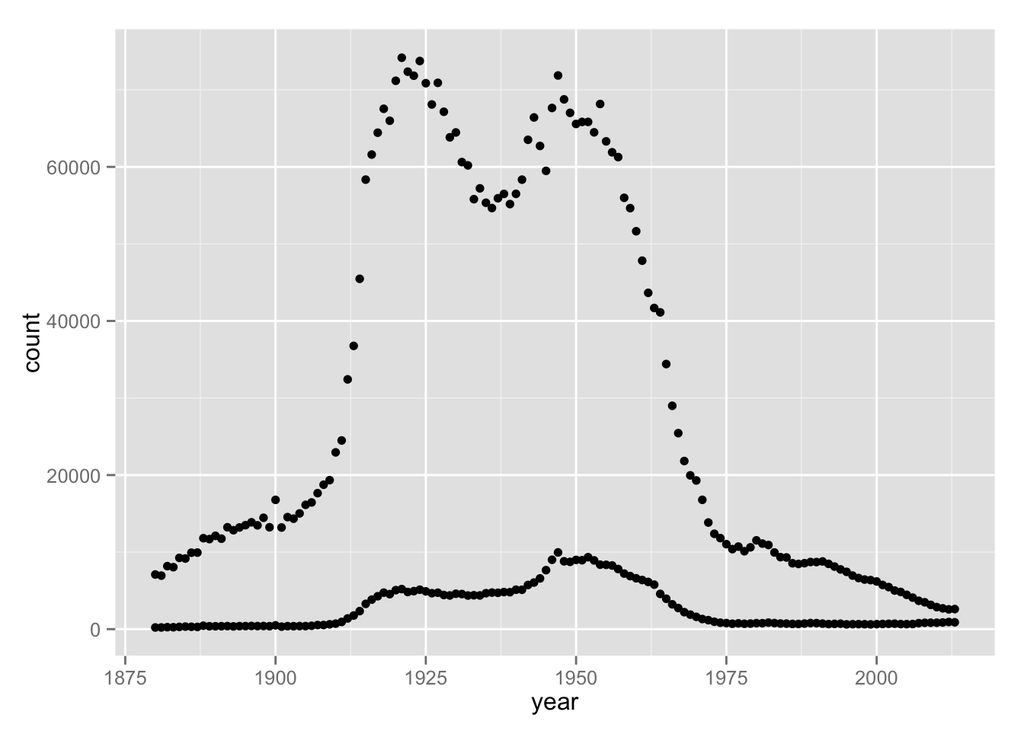

```r
ggplot(data=Result, aes(x = year, y = count)) +
  geom_point()
```

- *Map* the name (Mary or Jane) to the aesthetic of color. Remember that mapping to aesthetics is always done inside the `aes()` function.
- Instead of using dots as the glyph, use a line that connects consecutive values: `geom_line()`.
- Change the y-axis label to “Yearly Births”: `+ ylab("Yearly Births")`
- *Set* the line thickness to `size=2`. Remember that “setting” refers to adjusting the value of an aesthetic to a constant. Thus, it’s *outside* the `aes()` function.

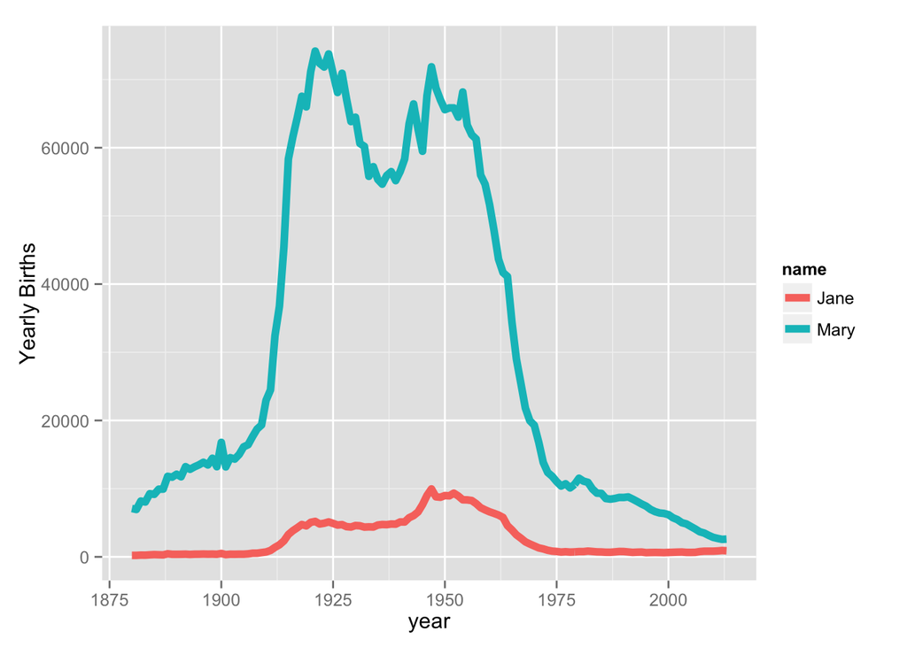

```r
ggplot(data=Result, aes(x = year, y = count)) +
  geom_line(aes(color = name), size=2) +
  ylab("Yearly Births")
```

### 3. Look at the *proportion* of births rather than the count

```r
Result2 <-
  BabyNames %>%
  group_by(year) %>%
  mutate(total = sum(count)) %>%
  filter(name %in% c("Mary", "Jane")) %>%
  mutate(proportion = count / total)
```

- Why is `sex` a variable in `Result2`? Eliminate it, keeping just the girls.

  ```r
  Result2 <-
    BabyNames %>%
    filter(sex == "F") %>%
    group_by(year) %>%
    mutate(total = sum(count)) %>%
    filter(name %in% c("Mary", "Jane")) %>%
    mutate(proportion = count / total)
  ```

- What happens if the `filter()` step is put *before* the `mutate()` step?

The `total` is just for Mary and Jane, ignoring all the other babies.

- Graph the results

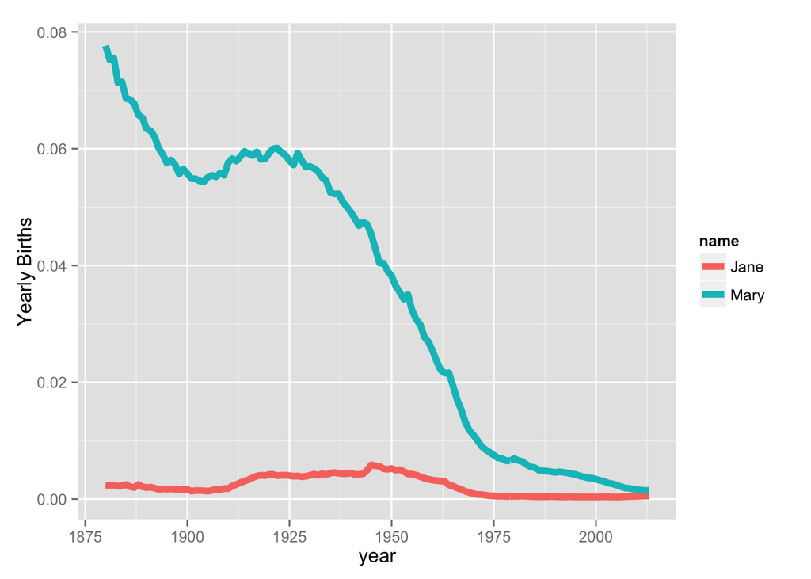

```r
ggplot(data=Result2, aes(x = year, y = proportion)) +
  geom_line(aes(color = name), size=2) +
  ylab("Yearly Births")
```

- Add a vertical line to mark a year in which something happened that might relate to the increase or decrease the popularity of the name. Example: The movie [*Whatever Happened to Baby Jane*](http://en.wikipedia.org/wiki/What_Ever_Happened_to_Baby_Jane%3F_%281962_film%29) came out in 1962. The glyph is a vertical line: `geom_vline()`.

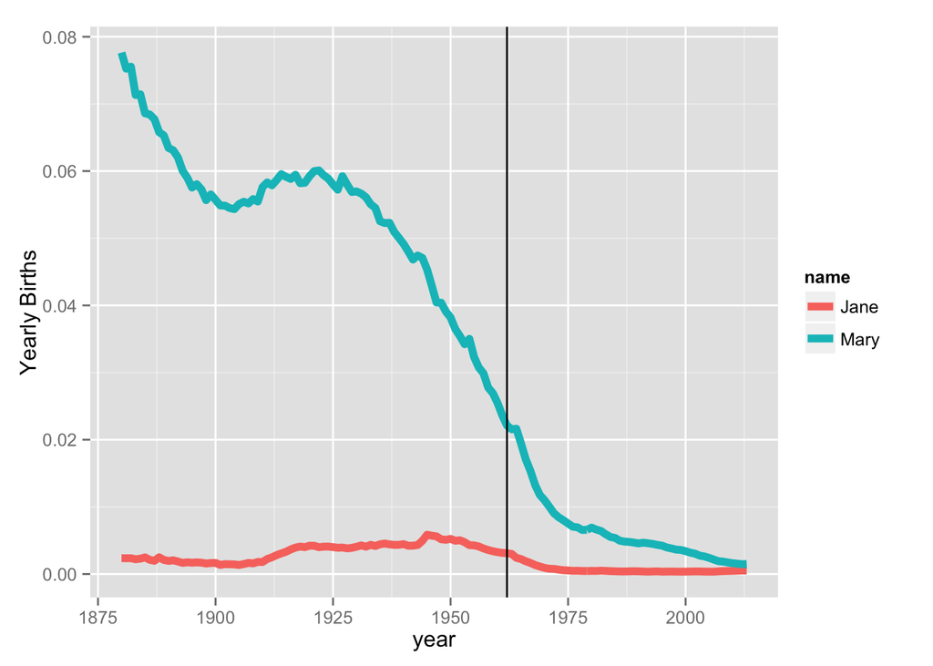

```r
ggplot(data=Result2, aes(x = year, y = proportion)) +
  geom_line(aes(color = name), size=2) +
  ylab("Yearly Births") +
  geom_vline(x=1962)
```